# Advanced Data Analytics

Loukas Gonzalez

Simon Alvarez Bliffeld

Simon Gonzalez

Yannik Biebert

2023-12-21

For the final project of Advanced Data Analytics, we decided to analyze three variables of two different countries and, with them, find and dissect valuable information with which we can create forecasts. The two countries that we decided on were Italy and the US. These countries, with their diverse economic landscapes, wield significant global influence, and despite their distinct economic landscapes, share a profound impact on the global stage.

The variables that we will be using will be the following: GDP, CPI, and Stock Market Index. GDP, measuring a nation’s total economic output, serves as a primary focus. An increase in GDP signifies economic growth, leading to job creation and higher incomes. Conversely, a decrease in GDP suggests a recession, bringing about unemployment and income reductions. The CPI, or Consumer Price Index, plays a pivotal role in understanding how prices for everyday goods and services are changing, offering insights into inflation and its impact on the cost of living. The Stock Market Index, another vital variable, tracks and represents the collective performance of selected stocks within each nation’s equity market. Changes in the Stock Market Index are closely tied to the confidence in a country’s economy, reflecting investor sentiment and overall economic conditions. We wanted to use these variables as it has been proven that they are correlated, with examples such as the “positive and significant relationship between GDP and CPI” (Mahmoud, 2015). Our main goal for doing this project is to understand the economic health of each country, see how the variables relate to each other, and understand how we can predict the future, and we want to observe what these predictions are. This type of work is very important in the real world, as it can help policymakers understand the state of their country’s economy, and with this, advise them in creating measures that can stabilize it and overall aid the country.

Therefore, we start the project with the question ‘How are the CPI, GDP, and Stock Market Index of Italy and the US related to each other, and how can predictions help policymakers?’.

# Part 0: Literature review

In the flowing part a literate review about time series analysis in combination with the GDP, CPI and stocks, as well as the countries USA and Italy will be conducted. It is already known in the economic community, that the economic growth and health of a country can not only be measured by the GDP, and an ARIMA analysis of this alone is not enough. This is also why sometimes countries can be growing in GDP and still have bad economic health. Cobb et al. (1995)] This is also the reason why we are using multiple variabels. As a first step looking at the connection between GDP and inflation, literature revealed, that a too high inflation has a negative impact on the economy. The paper notes that the point at which a higher CPI affects GDP the most is at a CPI of 7%. Before that it does not seem to have a negative impact. (Ayyoub et al., 2011) This can help policy makers to understand limits of CPI that should not be surpassed and where our analysis can help to predict them. The strong connection of GDP and CPI as well as their indication of economic health is also supported in (Ghazo, 2021), since they used the same approach for predicting economic growth. The paper discovered that increasing CPI and increasing GDP mean cost-push inflation, whereas decreasing GDP and rising cpi mean stagflation. (Ghazo, 2021) Shifting focus to the stock market’s relationship with economic growth, literature shows that the stock market is as a reliable indicator. This relationship is explored in many studies one of which is referenced by (Guha Deb and Mukherjee, 2008). Regarding modeling, ARIMA is still considered a very good approach and although it is outperformed by deep learning, it is still better with regards of computational time (Namin and Namin, 2018). Also leaving out the covid data is supported by literature as well, because it is important to evaluate extraordinary events separately (Liu et al., 2020)

# Part 1: Prepare and inspect the data

## 1.1 Importing and inspecting the data

```r
# import packages
library(pacman)
p_load(
  readxl, tseries, tidyverse, dplyr, tidyr, forecast, fpp2, stats, quantmod, zoo, lubridate,
  ggplot2, cowplot, rugarch)

# import data set xlxs
data <- read_excel("Datasets.xlsx")

# removing not used columns Housing and Unemployment
data <- data[, -c(7, 9)]


# Display the data set
print(data)
```

```
## # A tibble: 576 × 8
##    Country Code  ContinentCode  Year Month GDP, billion curren…¹ Consu…² Stock…³
##    <chr>   <chr> <chr>         <dbl> <dbl>                 <dbl>   <dbl>   <dbl>
##  1 Italy   ITA   EU             2000     1                   NA     73.2    144.
##  2 Italy   ITA   EU             2000     2                   NA     73.5    163.
##  3 Italy   ITA   EU             2000     3                  290.    73.7    172.
##  4 Italy   ITA   EU             2000     4                   NA     73.7    158.
##  5 Italy   ITA   EU             2000     5                   NA     74      161.
##  6 Italy   ITA   EU             2000     6                  309.    74.2    164.
##  7 Italy   ITA   EU             2000     7                   NA     74.4    167.
##  8 Italy   ITA   EU             2000     8                   NA     74.4    166.
##  9 Italy   ITA   EU             2000     9                  302.    74.6    167.
## 10 Italy   ITA   EU             2000    10                   NA     74.8    161.
## # … with 566 more rows, and abbreviated variable names
## #   ¹`GDP, billion currency units`, ²`Consumer Price Index (CPI)`,
## #   ³`Stock market index`
```

As observed, the years that we will be using for this analysis are from 2000 to 2020, giving us a comprehensive analysis of each country’s variables throughout the 21st century. The data were collected monthly with the exception of GDP, which was collected quarterly.

## 1.2 Prepare the data

```r
# Split the data into two dataframes based on the country
data_italy <- subset(data, Country %in% c("Italy"))
data_usa <- subset(data, Country %in% c("USA"))

# Function for data transformation
transform_data <- function(df) {
  # Extract columns from the dataframe
  gdp <- df$'GDP, billion currency units'
  cpi <- df$'Consumer Price Index (CPI)'
  stocks <- df$'Stock market index'

  # Drop missing values (becuase only every quarter)
  gdp <- na.omit(gdp)

  # Drop missing values (becuase last in the month)
  cpi <- na.omit(cpi)
  stocks <- na.omit(stocks)

  # Change to time series
  gdp <- ts(gdp, start = c(2000, 1), frequency = 4)
  cpi <- ts(cpi, start = c(2000, 1), frequency = 12)
  stocks <- ts(stocks, start = c(2000, 1), frequency = 12)

  # Drop everything after 2019
  gdp <- window(gdp, end = c(2019, 4))
  cpi <- window(cpi, end = c(2019, 12))
  stocks <- window(stocks, end = c(2019, 12))

  # Return the time series as separate variables
  return(list(gdp = gdp, cpi = cpi, stocks = stocks))
}

# Apply the transformation function
transformed_italy  <- transform_data(data_italy)
transformed_usa <- transform_data(data_usa)
```

After analyzing the data, we decided to omit the information from 2020 onwards. The Covid pandemic in 2020 significantly disrupted global economic patterns, causing unprecedented fluctuations in GDP, CPI, and Stock Market Indices. The widespread lockdowns, supply chain disruptions, and shifts in consumer behavior during the pandemic created outliers in the data that could skew our analysis and adversely affect the accuracy of our forecasts.

## 1.3 Visual inspection of the data

In the next part we will analys the data visually. We will plot the data and zoom in on a 4 year period. This will give us a better understanding of the data and how it is distributed, as well as potential seasonality and trends.

### 1.3.1 GDP Italy

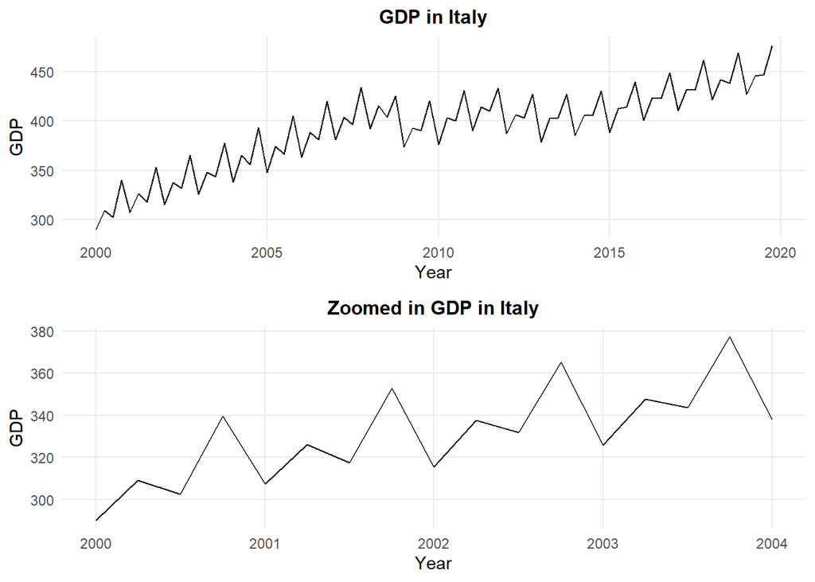

```r
# Create a function for visualization.
plot_and_zoom <- function(data, variable, country,num_years) {

  # Extract the specified number of years from the time series
  end_date <- start(data) + c(num_years, 0)
  window_data <- window(data, start = start(data), end = end_date)

  # Create the main plot
  main_plot <- ggplot(data, aes(x = time(data), y = as.numeric(data))) +
    geom_line() +
    theme_minimal() +
    labs(title = paste0(variable, ' in ', country), x = "Year", y = variable) +
    theme(panel.grid.minor = element_blank(),
      plot.title = element_text(size = 12, face = "bold", hjust = 0.5))

  # Create a zoomed-in version with the specified number of years
  zoomed_in_plot <- ggplot(window_data, aes(x = time(window_data), y = as.numeric(window_data))) +
    geom_line() +
    labs(title = paste0('Zoomed in ',variable, ' in ', country), x = "Year", y = variable) +
    theme_minimal() +
    theme(panel.grid.minor = element_blank(),
      plot.title = element_text(size = 12, face = "bold", hjust = 0.5))

  plot_grid(main_plot, zoomed_in_plot, ncol = 1)

}

# Plot the GDP for Italy
plot_and_zoom(transformed_italy$gdp, 'GDP', 'Italy', 4)
```

We can make some observations by looking at the graph of Italy’s GDP from 2000 - 2020. The GDP shows a clear upward trend, with a sharper increase from 2000 to 2008, where it stabilizes, and again an increase from 2015-2020. The interruption in the trend corresponds to the 2008 financial crisis, which shook the economy and its growth. We can also note a seasonality throughout the time series. Italy’s economy after 2001 began to slow down, even though the GDP is seen to be growing, the rate of growth had decreased. Factors such as “aging population, inflation, stagnation, and the impact of globalization on trade and demand” heavily affected the country’s development and economic growth. (Ardeni and Gallegati, 2023)

Italy’s development is slow mainly when compared to other countries European countries with similar capabilities and factors. We can observe another factor in the zoomed version of Italy’s GDP. The plot shows a clear trend or pattern of seasonality, wherein in the first part of the year we observe a slight increase in the GDP, followed by a sharper increase in the second part of the year, and this is observed in all of the years included. This could be attributed to factors such as traditional vacation patterns, tourism peaks, or specific industry behaviors.

### 1.3.2 CPI Italy

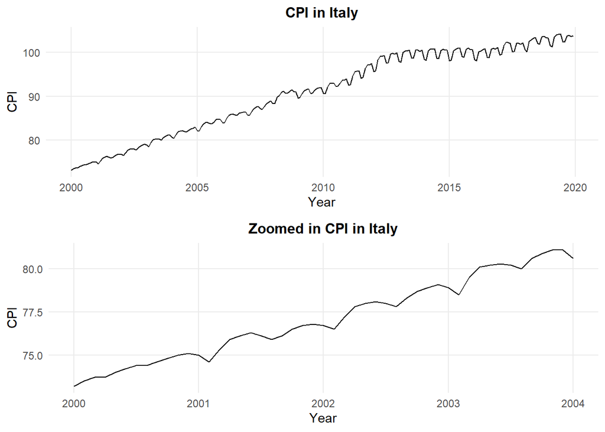

```r
# Plot the CPI for Italy
plot_and_zoom(transformed_italy$cpi, 'CPI', 'Italy', 4)
```

Italy’s CPI has seen a similar path to the GDP. From 2000 onwards, Italy’s Consumer Price Index (CPI) has undergone fluctuations influenced by various economic factors. In the early 2000s, the CPI experienced constant growth, which continued until 2012, when it began to slow down and reduce the growth rate. This might be the consequence on the financial crisis, combined with internal economic and political issues. The zoomed plot also reveals seasonality, as we can observe dips in the CPI in the first part of each year for all of the observed periods. This could be attributed to high spending seasons of the year, as it usually is found in most CPI plots, such as holidays.

### 1.3.3 Stock Italy

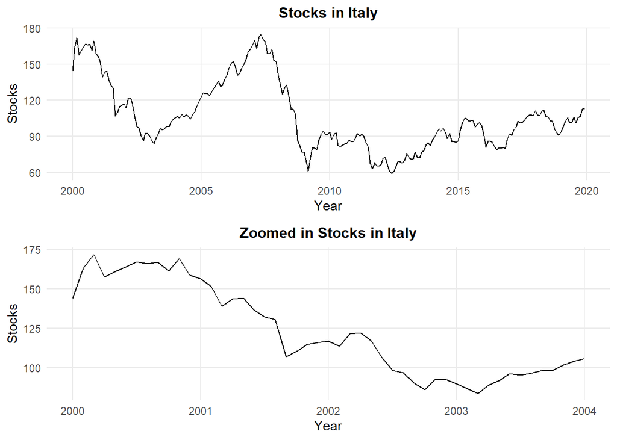

```r
# Plot stocks for Italy
plot_and_zoom(transformed_italy$stocks, 'Stocks', 'Italy', 4)
```

The Stock Market Index for Italy is very different from the previous charts and datasets. As observed, the market had many fluctuations throughout the 2000 - 2020 period. We can observe that from 2000 to 2003, Italy’s stock market had a steep decline, followed by a rapid growth period that was again stopped by the financial crisis of 2008-2009. The index maintained high volatility for the following period, with short periods of growth or decline, but with an overall positive growth trend. Again, most of the behavior of the market is related to political decisions that the Italian government has made and external economic factors influencing investor confidence. Notably, the stock market showed increased volatility during times of political unpredictability or changes in governmental policy. Furthermore, the overall state of the world economy, particularly the Eurozone crisis, had a big impact on how the Italian stock market developed (Lessons from italy’s economic decline).

### 1.3.4 GDP USA

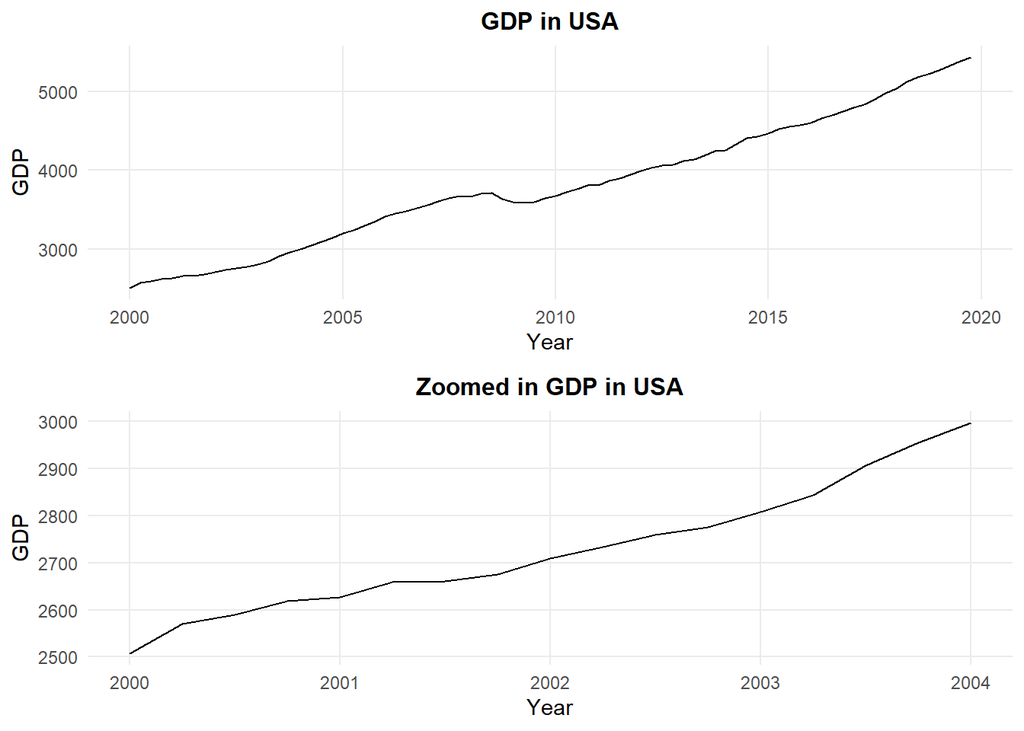

```r
# Plot GDP for USA
plot_and_zoom(transformed_usa$gdp, 'GDP', 'USA', 4)
```

### 1.3.5 CPI USA

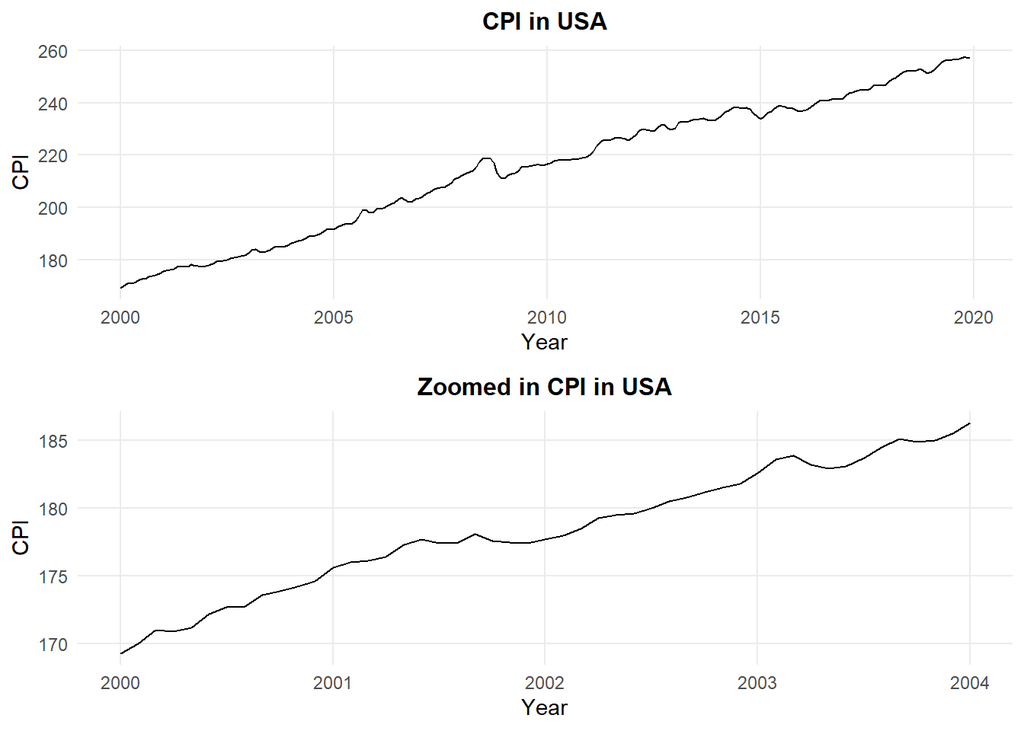

```r
# Plot CPI for USA
plot_and_zoom(transformed_usa$cpi, 'CPI', 'USA', 4)
```

The USA’s CPI follows a very positive trend, with continuous growth throughout the period observed. We can observe certain moments of slowdown, specifically after the 2008 financial crisis, but even with this, the CPI is constantly growing, at a somewhat slow rate. No seasonality or specific pattern can be observed in the plot or the zoomed plot. This upward trend points to an economy that is typically growing and stable, with rare setbacks like the financial crisis eventually being resolved. These variations in the growth rate could also be a sign of the economy’s resiliency and capacity to bounce back from setbacks, which would explain the CPI’s general upward tendency.

### 1.3.6 Stocks USA

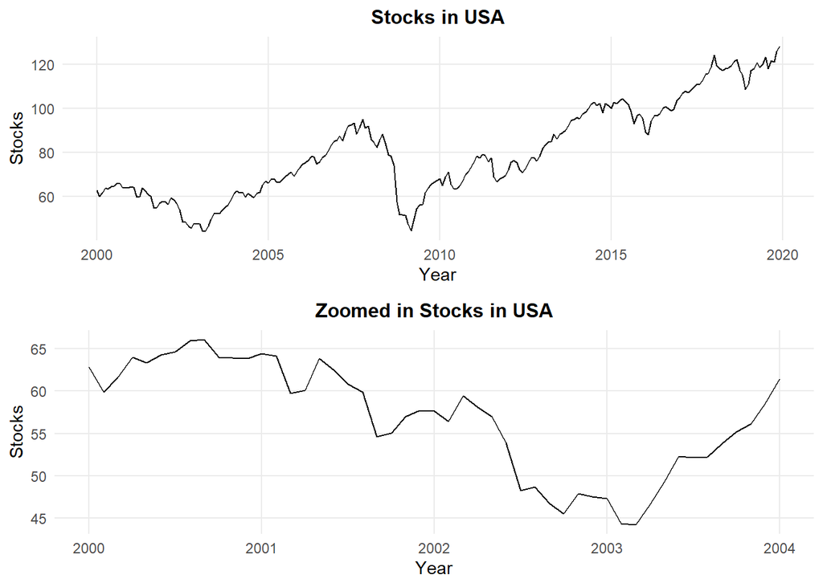

```r
# Plot stocks for USA
plot_and_zoom(transformed_usa$stocks, 'Stocks', 'USA', 4)
```

The Stock Market index for the USA different from what we observed in Italy, shows a clear upward trend, with some periods of higher volatility and shifts. Again, as noted in all of the previous plots, we see a period of decline right in 2008, which corresponds to the financial crisis, where gains were lost in a very short period. The U.S. stock market proved strong after this trying time, rising and showing a steady growth trend, confirming the economy’s capacity to come back from difficult periods. The U.S. financial system’s inherent flexibility and the proactive actions of policymakers are frequently credited for this recovery.

## 1.4 Train test split

```r
# Function for train test split
train_test_split <- function(data_list, train_percentage = 0.8) {
  split_data <- list()

  # Loop through the variables in the list
  for (variable in names(data_list)) {
    ts_data <- data_list[[variable]]
    data_length <- length(ts_data)

    # Calculate the train size
    train_size <- round(train_percentage * data_length)

    # Train split, this way needed, to keep the ts format
    train_data <- ts(ts_data[1:train_size], start = start(ts_data), frequency = frequency(ts_data))

    end_time <- time(train_data)[length(train_data)]

    # Get start for testdata, if only split with [:] the ts type is lost as well as the start time
    if (frequency(ts_data) == 12) {
      end_time <- end_time + 1/12
      start_year <- floor(end_time)
      start_month <- (end_time - start_year) * 12 + 1
    } else if (frequency(ts_data) == 4) {
      end_time <- end_time + 1/4
      start_year <- floor(end_time)
      start_month <- (end_time - start_year) * 4 + 1
    } else {
      print('Error: Frequency not supported')
    }

    test_data <- ts(ts_data[(train_size + 1):data_length], start = c(start_year, start_month), frequency = frequency(ts_data))

    # Add the data to the list
    split_data[[paste0(variable, "_train")]] <- train_data
    split_data[[paste0(variable, "_test")]] <- test_data
  }

  return(split_data)
}

# Apply the train test split function
split_italy <- train_test_split(transformed_italy)
split_usa <- train_test_split(transformed_usa)
```

Splitting the data into a train and a test part is important to evaluate the models. By only splitting with [:] the ts type is lost as well as the start time. Therefore the function above is needed.

```r
# Italy variables
gdp_italy_train <- split_italy$gdp_train
gdp_italy_test <- split_italy$gdp_test

cpi_italy_train <- split_italy$cpi_train
cpi_italy_test <- split_italy$cpi_test

stocks_italy_train <- split_italy$stocks_train
stocks_italy_test <- split_italy$stocks_test

# USA variables
gdp_usa_train <- split_usa$gdp_train
gdp_usa_test <- split_usa$gdp_test

cpi_usa_train <- split_usa$cpi_train
cpi_usa_test <- split_usa$cpi_test

stocks_usa_train <- split_usa$stocks_train
stocks_usa_test <- split_usa$stocks_test
```

The different variables are extracted from the list. Those variables are used for the model fitting.

## 1.5 Evaluate the data

To get a deeper understanding of suitable models we will evaluate the data. There the ACF and PACF, as well as stationarity is analyzed.

### 1.5.1 GDP Italy

```
## Results for GDP in Italy :
## ADF Test:
##   P-Value: 0.8352205
## Number of Differences Required for Stationarity: 1
```

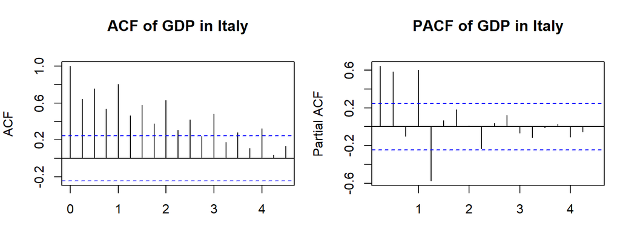

```r
# Analyse the different variables for stationarity
analyze_time_series <- function(ts_data, country, variable) {

  # Doing the ADF and PP test, as well as determining diff
  adf_result <- tseries::adf.test(ts_data)
  num_diffs <- ndiffs(ts_data)

  # Print results for the current variable
  cat("Results for", variable, "in", country, ":\n")
  cat("ADF Test:\n")
  cat("  P-Value:", adf_result$p.value, "\n")
  cat("Number of Differences Required for Stationarity:", num_diffs, "\n\n")

  # Set up the plot
  par(mfrow = c(1, 2), mar = c(3, 4, 4, 1))

  # ACF and PACF plots
  acf(ts_data, main = paste("ACF of", variable, "in", country))
  pacf(ts_data, main = paste("PACF of", variable, "in", country))
}

# Explore gdp of Italy
analyze_time_series(gdp_italy_train, "Italy", 'GDP')
```

In our financial analysis of Italy’s GDP, the Autocorrelation Function (ACF) displayed over 15 significant lags, as well as the before seen seasonal pattern. Due to the slow decline we might conclude that it is an AR model. This is further supported due to the steep decline in the Partial Autocorrelation Function (PACF) after the fifth lag. Also the Model will probably include a seasonal component. Since is is quarterly and could already be seen in the plotted data. This might even reduce the PACF lags to 1. The Augmented Dickey-Fuller (ADF) test has a p-value of 0.83, which is more than 0.05, indicating that the data is non-stationary. The number of differences required for stationarity is 1.

```r
# Analyse the differenced variables for stationary
analyze_diff_series <- function(ts_data, country, variable, seasonal = 0) {

  # Getting number of differences required for stationarity
  num_diffs <- ndiffs(ts_data)

  # Differncing num_diffs times
  for (i in 1:num_diffs) {
    ts_data <- diff(ts_data)
  }

  if (seasonal != 0){
    ts_data <- diff(ts_data, lag = seasonal)
  }

  # Performing the ADF and PP test
  adf_result <- tseries::adf.test(ts_data)
  num_diffs_new <- ndiffs(ts_data)

  # Print results for the current variable
  cat("Results for", variable, "in", country, "with season", seasonal, ":\n")
  cat("ADF Test:\n")
  cat("  P-Value:", adf_result$p.value, "\n")
  cat("Number of Differences Required for Stationarity:", num_diffs_new, "\n\n")

}

# Difference data from Italy
analyze_diff_series(gdp_italy_train, "Italy", 'GDP')
```

```
## Results for GDP in Italy with season 0 :
## ADF Test:
##   P-Value: 0.6160956
## Number of Differences Required for Stationarity: 0
```

```r
analyze_diff_series(gdp_italy_train, "Italy", 'GDP', 4)
```

```
## Results for GDP in Italy with season 4 :
## ADF Test:
##   P-Value: 0.01
## Number of Differences Required for Stationarity: 0
```

After using the recommended number of differences of 1 on Italy’s GDP the Augmented Dickey-Fuller (ADF) test suggested evidence against stationarity with a p-value of 0.62, as well as no further differencing. Since this is not completely stationary the 4th difference is take, because a seasonal component was detected in the ploted data as well as the ACF and PACF. In the seasonal scenario, the ADF test provided strong evidence for stationarity with a p-value of 0.01. This suggests to use one difference in the modeling part, as well as including a SMA.

### 1.5.2 CPI Italy

```r
# Explore cpi of Italy
analyze_time_series(cpi_italy_train, "Italy", 'CPI')
```

```
## Results for CPI in Italy :
## ADF Test:
##   P-Value: 0.99
## Number of Differences Required for Stationarity: 1
```

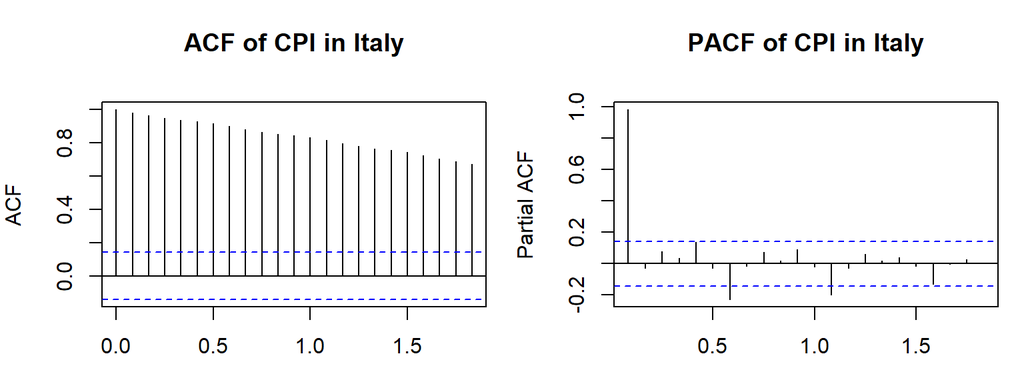

```r
# Explore cpi of Italy
analyze_diff_series(cpi_italy_train, "Italy", 'CPI')
```

```
## Results for CPI in Italy with season 0 :
## ADF Test:
##   P-Value: 0.02006838
## Number of Differences Required for Stationarity: 0
```

After using the recommended number of differences (1) on Italy’s CPI the Augmented Dickey-Fuller (ADF) test suggested stationarity, as well as no further differencing. But it can be seen that the value is still bigger then the other once before and taking the graphs into account as well a seasonal component can be expected.

### 1.5.3 Stocks Italy

```r
# Explore stocks of Italy
analyze_time_series(transformed_italy$stocks, "Italy", 'Stocks')
```

```
## Results for Stocks in Italy :
## ADF Test:
##   P-Value: 0.4086553
## Number of Differences Required for Stationarity: 1
```

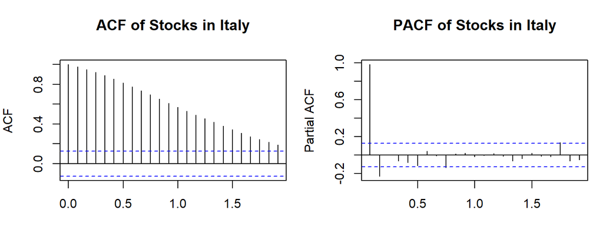

For Italy’s stock data the ADF has a p-value of 0.41 suggesting non-stationarity. Also it is recommended to difference once. The ACF shows a slow decline and since the PACF has a steep drop at lag 2, the model will probably be an AR(2). This will be tested in the modeling part.

```r
# Explore stocks of Italy
analyze_diff_series(stocks_italy_train, "Italy", 'Stocks')
```

```
## Results for Stocks in Italy with season 0 :
## ADF Test:
##   P-Value: 0.01
## Number of Differences Required for Stationarity: 0
```

After using the recommended number of differences (1) on Italy’s stock data the Augmented Dickey-Fuller (ADF) test suggested stationarity, as well as no further differencing is recommended.

### 1.5.4 GDP USA

```r
# Explore gdp of USA
analyze_time_series(transformed_usa$gdp, "USA", 'GDP')
```

```
## Results for GDP in USA :
## ADF Test:
##   P-Value: 0.8173736
## Number of Differences Required for Stationarity: 1
```

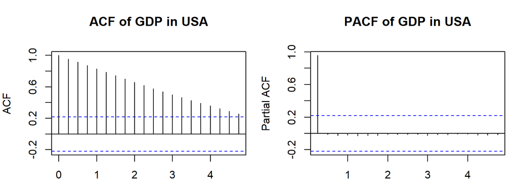

For USA GDP data the ADF test suggested with a p-value of 0.82 non-stationarity. Also taking one difference is recommended. The ACF shows a slow decline and since the PACF has a steep drop at lag 1, the model will probably be an AR(1). This will be tested in the modeling part.

```r
# Explore gdp of Italy
analyze_diff_series(gdp_usa_train, "USA", 'GDP')
```

```
## Results for GDP in USA with season 0 :
## ADF Test:
##   P-Value: 0.2957542
## Number of Differences Required for Stationarity: 0
```

```r
analyze_diff_series(diff(gdp_usa_train), "USA", 'GDP')
```

```
## Results for GDP in USA with season 0 :
## ADF Test:
##   P-Value: 0.01
## Number of Differences Required for Stationarity: 0
```

After using the recommended number of differences (1) on USA GDP the Augmented Dickey-Fuller (ADF) test suggested evidence against stationarity with a p- value of 0.29, as well as no further differencing. Since this is not completely stationary it was differenced once more and then the ADF test provided strong evidence for stationarity. This suggests using one difference in the modeling part, and inclcuding a drift.

### 1.5.5 CPI USA

```r
# Explore cpi of USA
analyze_time_series(cpi_usa_train, "USA", 'CPI')
```

```
## Results for CPI in USA :
## ADF Test:
##   P-Value: 0.89026
## Number of Differences Required for Stationarity: 1
```

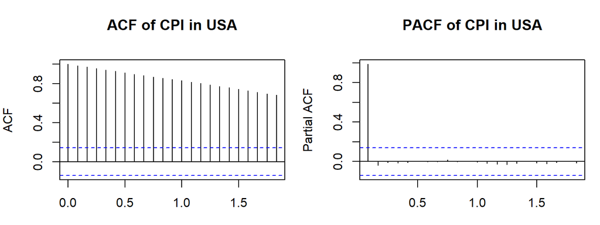

For USA cpi data the ADF test has a p-value of 0. 0.89 suggesting non-stationarity. Also taking one difference is recommended. The ACF shows a slow decline and since the PACF has a steep drop at lag 1, the model will probably be an AR(1). This will be tested in the modeling part.

```r
# Explore cpi of Italy
analyze_diff_series(cpi_usa_train, "USA", 'CPI')
```

```
## Results for CPI in USA with season 0 :
## ADF Test:
##   P-Value: 0.01
## Number of Differences Required for Stationarity: 0
```

After using the recommended number of differences on USA cpi the Augmented Dickey-Fuller (ADF) test rejects the H0 hypothesis, and suggests stationary. This suggests using one difference in the modeling part.

### 1.5.6 Stocks USA

```r
# Explore stocks of USA
analyze_time_series(stocks_usa_train, "USA", 'Stocks')
```

```
## Results for Stocks in USA :
## ADF Test:
##   P-Value: 0.2018327
## Number of Differences Required for Stationarity: 1
```

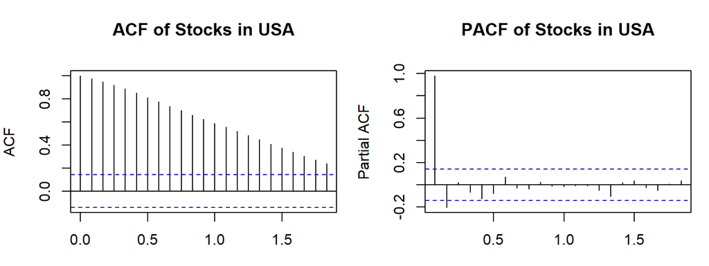

```r
# Explore stocks of Italy
analyze_diff_series(stocks_usa_train, "USA", 'Stocks')
```

```
## Results for Stocks in USA with season 0 :
## ADF Test:
##   P-Value: 0.01
## Number of Differences Required for Stationarity: 0
```

After using the recommended number of differences on USA stock the Augmented Dickey-Fuller test suggests stationarity. Also no further differencing is recommended.

## 1.6 Volatility clustering

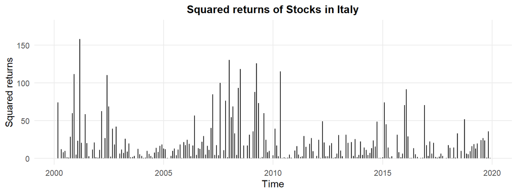

```r
plot_volatility_clusters <- function(time_series, country, variable, uper = 0) {

  # Calculate the squared returns
  time_series <- diff(time_series)^2

  if (uper == 0) {
    uper <- max(time_series) + max(time_series)*0.05
  }

  # Create the line plot
  ggplot(data.frame(time = time(time_series), value = time_series), aes(x=time,y=value))  +
    geom_segment(aes(xend = time, yend = 0)) +
    labs(title = paste("Squared returns of", variable, 'in', country),
         x = "Time",
         y = "Squared returns") +
    theme_minimal() +
    theme(panel.grid.minor = element_blank(),
      plot.title = element_text(size = 12, face = "bold", hjust = 0.5)) +
    scale_y_continuous(limits = c(0, uper))

}

# Plotting the volatility clustering
plot_volatility_clusters(transformed_italy$stocks, 'Italy', 'Stocks', 175)
```

The volatility clustering in Italy’s stock data represents the larger volatility during the dot com bubble of 2002 and the 2007 housing crisis. As a result of the volatility, GARCH is used as the preferred model to capture the most information. Additionally, GARCH is most efficient at capturing time-varying volatility within financial data.

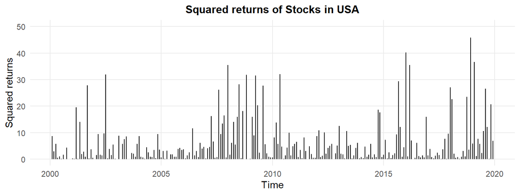

```r
# Plotting the volatility clustering
plot_volatility_clusters(transformed_usa$stocks, 'USA', 'Stocks', 50)
```

The volatility clustering of the US stock data highlights larger volatility during uncertain times such as the 2002 dot com bubble and 2007 housing crisis. Here the plot is zoomed cut of at a y value of 50 because otherwise the extream high volatility in the housing crisis would distort the plot. As a result of the volatility, GARCH is used as the preferred model to capture the most information.

# Part 2: Model

After inspecting the data and evaluating the different tests and plots as well as gathering information about features of the time series the modeling part can be started. The modeling part will be split into multiple parts. Before starting with ARIMA models, the data are split and the trend and sesonality of seasonal data are further inspected using the winter-holt method. After that the ARIMA models are created and evaluated.

First, different ARIMA models are created, based on the insides gathered before, as well as using the auto.arima function. Second, the best model is chosen and the residuals are inspected. If the residuals are not white noise, further models are created. Finally the best model is chosen and the forecasts are created and evaluated.

## 2.1 Trend and Seasonality with winter-holt

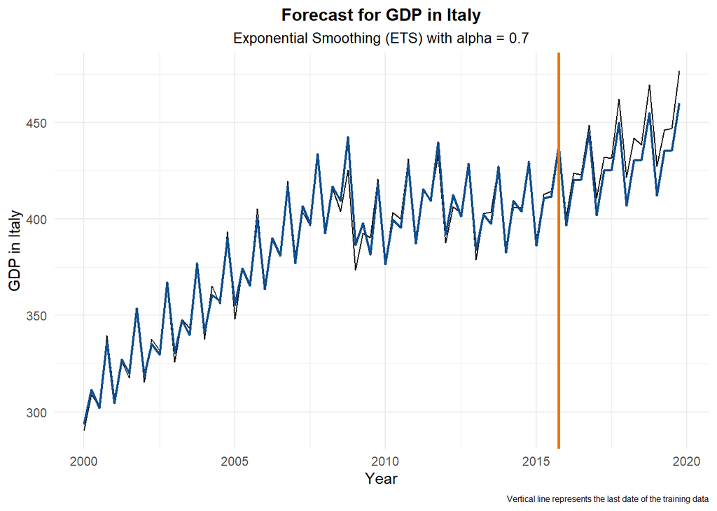

```r
plot_forecast <- function(train_data, test_data, ts_data, country, variable, alpha, model) {
  model_hw <- ets(train_data, model = model, alpha = alpha)
  ntest <- length(test_data)

  pred <- forecast(model_hw, h = ntest, level = 0)

  pred_hw <- c(model_hw$fitted, pred$mean)

  # Extract the last date of the training data
  last_date_train <- tail(time(train_data), 1)

  ggplot(data.frame(time = time(ts_data), value = ts_data, pred_hw = pred_hw)) +
    geom_line(aes(x = time, y = value, group = 1)) +
    geom_line(aes(x = time, y = pred_hw, group = 1), color = "dodgerblue4", size = 0.75) +
    geom_vline(aes(xintercept = as.numeric(last_date_train)), color = "darkorange2", size = 0.9) +
    xlab("Year") +
    ylab(paste(variable, "in", country)) +
    labs(title = paste("Forecast for", variable, "in", country),
         subtitle = paste("Exponential Smoothing (ETS) with alpha =", alpha),
         caption = "Vertical line represents the last date of the training data") +
    theme_minimal() +
    theme(plot.title = element_text(size = 12, face = "bold", hjust = 0.5),
          plot.subtitle = element_text(size = 10, hjust = 0.5),
          plot.caption = element_text(size = 6))

}

plot_forecast(gdp_italy_train, gdp_italy_test, transformed_italy$gdp, country = "Italy", variable = "GDP", alpha = 0.7, 'AAA')
```

The graph shows the predicted GDP values, considering factors like trends and seasons. The positive outlook suggests Italy’s GDP is on the rise after the 2007 crisis. Comparing it with Italy’s Consumer Price Index (CPI), we find that the forecasting model used here works well for GDP trends. In conclusion the tool helps us see future economic trends, and for Italy’s GDP, things are looking up. The forecasting methods used give us insights into economic patterns and potential future directions, which is fitting with the test data. It suggests a rising gdp and incorporates also the seasonal pattern, which allows decision makers to formulate adequate policies for a continuing healthy growth.

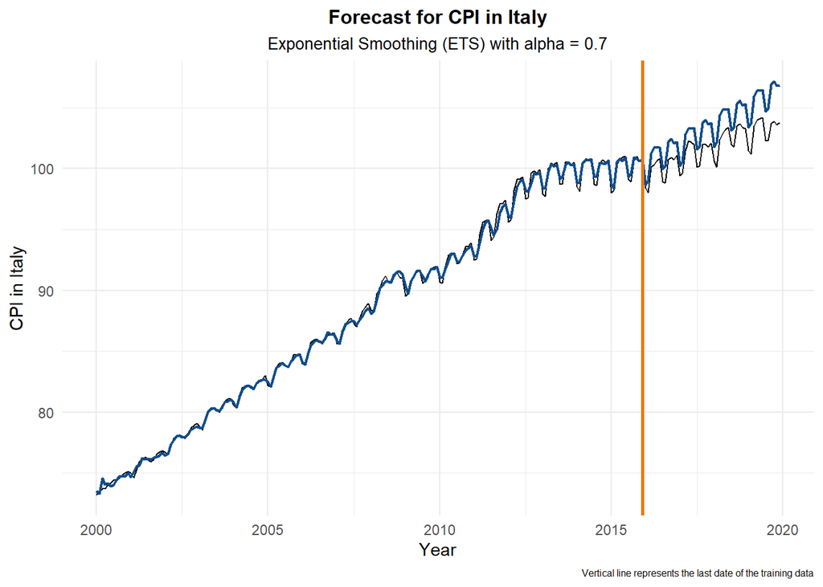

```r
plot_forecast(cpi_italy_train, cpi_italy_test, transformed_italy$cpi, country = "Italy", variable = "CPI", alpha = 0.7, 'AAA')
```

This insight is crucial for policymakers to prevent inflation and manage CPI effectively.

## 2.2 ARIMA

In the next step for vaiable a ARIMA respectively GARCH is developed.

### 2.2.1 GDP Italy

```r
# Function to format ARIMA order
format_arima_order <- function(arma) {
  non_seasonal <- paste(arma[1], arma[6], arma[2])
  seasonal <- paste(arma[3], arma[7], arma[4])
  period <- arma[5]
  return(paste("ARIMA(", non_seasonal, ")", "(", seasonal, ")", "[", period, "]", sep = ""))
}

# Function for model comparison
evaluate_arima_models <- function(models, test_data) {

  results <- data.frame(Model = character(), AIC = numeric(), SIC = numeric(), BIC = numeric(), Residuals = character(), MSPE = numeric())

  for (model in models) {
    fit <- model
    order <- coef(fit)

    # Extract AIC and SIC
    aic <- AIC(fit)
    sic <- AIC(fit, k = log(length(fit$residuals)))
    bic <- BIC(fit)

    # Check residuals for white noise
    white_noise <- Box.test(fit$residuals, lag = 20, type = "Ljung-Box")$p.value > 0.05
    residuals_check <- ifelse(white_noise, "White Noise", "Not White Noise")

    # Make predictions on test data
    pred <- forecast(fit, h = length(test_data))

    # Calculate MSPE
    mspe <- mean(((pred$mean - test_data) / test_data)^2, na.rm = TRUE)*100

    # Append results to the data frame
    name <- format_arima_order(model$arma)
    result_row <- data.frame(Model = name, AIC = aic, SIC = sic, BIC = bic, Residuals = residuals_check, MSPE = mspe)
    results <- rbind(results, result_row)
  }

  return(results)
}


# Crate different models
model_max_i_gdp <- forecast::Arima(gdp_italy_train, order = c(9, 1, 16), method = 'ML')

model_seasonal_i_gdp <- forecast::Arima(gdp_italy_train, order = c(1, 1, 0), seasonal = list(order = c(0, 1, 1), period = 4), method = 'ML')

model_aic_i_gdp <- auto.arima(gdp_italy_train, ic = 'aic')

model_bic_i_gdp <- auto.arima(gdp_italy_train, ic = 'bic')


# Create a list of models
model_list <- list(model_max_i_gdp, model_seasonal_i_gdp, model_aic_i_gdp, model_bic_i_gdp)

# Evaluate the models
evaluate_arima_models(model_list, gdp_italy_test)
```

```
##                     Model      AIC      SIC      BIC   Residuals       MSPE
## 1 ARIMA(9 1 16)(0 0 0)[4] 393.5605 449.6914 449.2820 White Noise 0.08617771
## 2  ARIMA(1 1 0)(0 1 1)[4] 334.9751 341.4517 341.2077 White Noise 0.02389399
## 3  ARIMA(0 1 2)(0 1 1)[4] 334.4106 343.0462 342.7208 White Noise 0.02517333
## 4  ARIMA(1 1 0)(0 1 1)[4] 334.9751 341.4517 341.2077 White Noise 0.02389385
```

The ARIMA models we developed correspond to the following characteristics. The first function takes into consideration all the spikes of ACF and PACF and incorporates 9 autoregressive terms and 16 moving average terms, and overall uses the maximum lags. The second model uses seasonality as the main target for the modeling and tells us that it requires differencing for stationarity and for seasonal stationarity. The third uses as the parameter the lowest AIC, in this case, 334.4106, and the fourth model the lowest BIC, which was 341.2077.

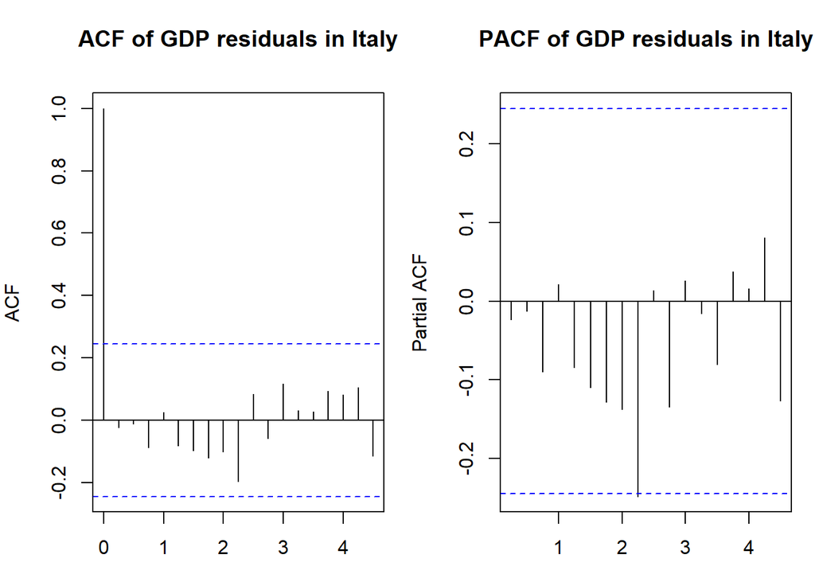

```r
plot_residuals_arima <- function(model, country, variable){

  # Set up the plot
  par(mfrow = c(1, 2), mar = c(3, 4, 4, 1))

  # ACF and PACF plots
  acf(model$residuals, main = paste("ACF of", variable, "residuals in", country))
  pacf(model$residuals, main = paste("PACF of", variable, "residuals in", country))
}



plot_residuals_arima(model_aic_i_gdp, "Italy", "GDP")
```

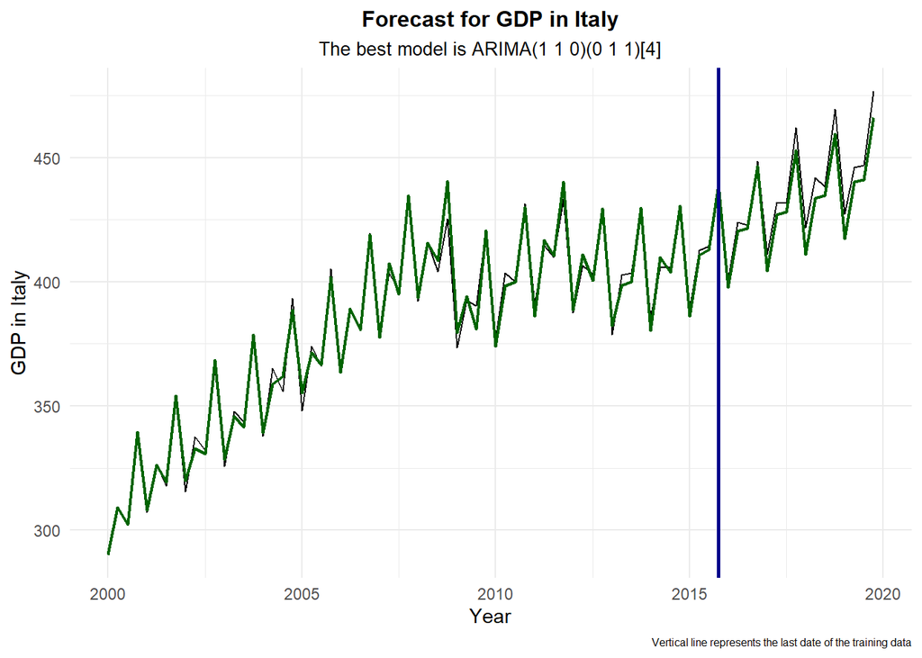

```r
# Plot the forecast
plot_forecast_arima <- function(train_data, test_data, ts_data, country, variable, model) {
  ntest <- length(test_data)
  pred <- forecast(model, h = ntest, level = 0)
  pred_arima <- c(model$fitted, pred$mean)

  # Extract the last date of the training data
  last_date_train <- tail(time(train_data), 1)

  name <- format_arima_order(model$arma)

  ggplot(data.frame(time = time(ts_data), value = ts_data, pred_arima = pred_arima)) +
    geom_line(aes(x = time, y = value, group = 1)) +
    geom_line(aes(x = time, y = pred_arima, group = 1), color = 'darkgreen', size=0.75) +
    geom_vline(aes(xintercept = as.numeric(last_date_train)), color = "darkblue", size = 0.9) +
    xlab("Year") +
    ylab(paste(variable, "in", country)) +
    labs(title = paste("Forecast for", variable, "in", country),
         subtitle = paste("The best model is", name),
         caption = "Vertical line represents the last date of the training data") +
    theme_minimal() +
    theme(plot.title = element_text(size = 12, face = "bold", hjust = 0.5),
          plot.subtitle = element_text(size = 10, hjust = 0.5),
          plot.caption = element_text(size = 6))
}

plot_forecast_arima(gdp_italy_train, gdp_italy_test, transformed_italy$gdp, "Italy", "GDP", model_bic_i_gdp)
```

As observed in the plot, the forecast we achieved with this model is the most accurate one, and it is by using the ARIMA. The predicted or forecasted plot follows with a very small range of difference from the real line, confirming the model’s accuracy. This model can be used to predict the GDP of Italy and therefore guide policy makers to make decisions based on the forecaster values. They can be used to help a strong growing economy to keep growing or to help a weak economy to recover.

### 2.2.2 CPI Italy

```r
# TODO maybe look at seasonal self composed once?

# Creating different models
model_med_i_cpi <- forecast::Arima(cpi_italy_train, order = c(7, 1, 0))
model_aic_i_cpi <- auto.arima(cpi_italy_train, ic = 'aic')
model_bic_i_cpi <- auto.arima(cpi_italy_train, ic = 'bic')

model_6_i_cpi <- forecast::Arima(cpi_italy_train, order = c(6, 1, 0))

# Create a list of models
model_list <- list(model_med_i_cpi, model_aic_i_cpi, model_bic_i_cpi)

# Evaluate the models
evaluate_arima_models(model_list, cpi_italy_test)
```

```
##                     Model       AIC      SIC       BIC       Residuals
## 1 ARIMA(7 1 0)(0 0 0)[12] 132.00259 158.0626 158.02078 Not White Noise
## 2 ARIMA(0 1 0)(1 1 0)[12]  34.12551  40.6405  40.50028 Not White Noise
## 3 ARIMA(0 1 0)(1 1 0)[12]  34.12551  40.6405  40.50028 Not White Noise
##         MSPE
## 1 0.05914982
## 2 0.03536577
## 3 0.03536577
```

We tried different approaches to forecast Italy’s Consumer Price Index (CPI). First, we manually selected an ARIMA(7, 1, 0) model based on significant lags. Then, we used auto ARIMA models, considering AIC and BIC for selection. The evaluation showed that the ARIMA(7, 1, 0) model had the highest AIC, and its residuals didn’t behave like white noise, indicating overfitting. The best models were seasnal models with an SAR. But those as well did not have White Noise residuals.

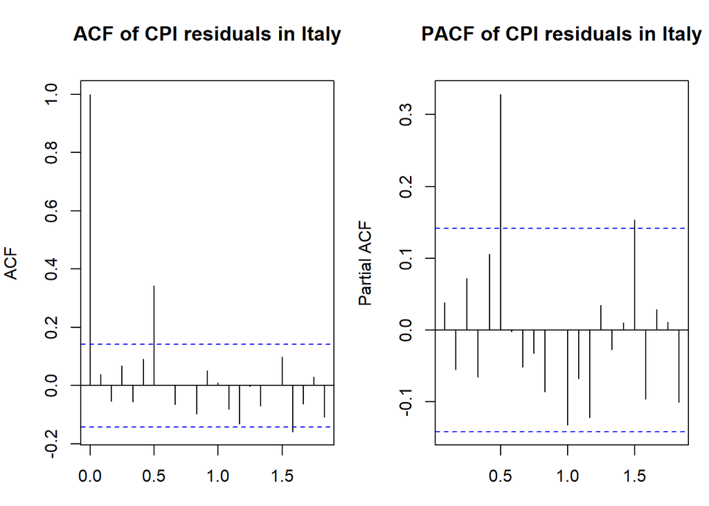

```r
# Plot the residuals of the best model
plot_residuals_arima(model_aic_i_cpi, "Italy", "CPI")
```

The ACF and PACF visuals for Italy’s CPI residuals indicate violations, notably with a significant spike in both plots, suggesting unaccounted patterns. These patterns may necessitate the consideration of larger models to improve forecasting accuracy. There it is important to prevent overfitting and one method is to drop not significant parameters to still keep the model as simple as possible, while using pattern in higher order lags. Only with accurate models decision makers can relay on the forecasted values.

```r
seasonal_4_6_i_c <- forecast::Arima(cpi_italy_train, order = c(0, 1, 0), seasonal = list(order = c(4, 1, 0), period = 6))

seasonal_4_12_i_c <- forecast::Arima(cpi_italy_train, order = c(0, 1, 0), seasonal = list(order = c(4, 1, 0), period = 12))

seasonal_2_6_i_c <- forecast::Arima(cpi_italy_train, order = c(0, 1, 0), seasonal = list(order = c(2, 1, 0), period = 6))

seasonal_2_12_i_c <- forecast::Arima(cpi_italy_train, order = c(0, 1, 0), seasonal = list(order = c(2, 1, 0), period = 12))

seasonal_1_6_i_c <- forecast::Arima(cpi_italy_train, order = c(0, 1, 0), seasonal = list(order = c(1, 1, 0), period = 6))

model_list <- list(model_aic_i_cpi, seasonal_4_6_i_c, seasonal_4_12_i_c, seasonal_2_6_i_c, seasonal_2_12_i_c, seasonal_1_6_i_c)

# Evauate model
evaluate_arima_models(model_list, cpi_italy_test)
```

```
##                     Model       AIC      SIC      BIC       Residuals
## 1 ARIMA(0 1 0)(1 1 0)[12] 34.125509 40.64050 40.50028 Not White Noise
## 2  ARIMA(0 1 0)(4 1 0)[6]  2.404674 18.69215 18.50645     White Noise
## 3 ARIMA(0 1 0)(4 1 0)[12] 39.372160 55.65964 55.30909 Not White Noise
## 4  ARIMA(0 1 0)(2 1 0)[6] 15.869981 25.64247 25.53105     White Noise
## 5 ARIMA(0 1 0)(2 1 0)[12] 36.050366 45.82285 45.61252 Not White Noise
## 6  ARIMA(0 1 0)(1 1 0)[6] 16.820719 23.33571 23.26143     White Noise
##         MSPE
## 1 0.03536577
## 2 0.05907675
## 3 0.05759134
## 4 0.05131614
## 5 0.03618340
## 6 0.05009975
```

We explored various seasonal ARIMA models to improve forecasting for Italy’s CPI. Notably, models with different seasonal periods (6 and 12) with different orders of seasonal components (1,2, and 4) were tested. Evaluation results showed that while the model with a seasonal period of 6 and 4 parameters had the lowest AIC, its MSPE in the test data was high, suggesting less accurate predictions. This underscores the importance of considering both AIC and MSPE. Additionally, the visual observation that a seasonal pattern occurs every 6 periods aligns with our exploration of different seasonal periods. This analysis guides us in selecting the most effective model for precise CPI forecasting, with potential improvements compared to the initial model or the Winter-Holt method.

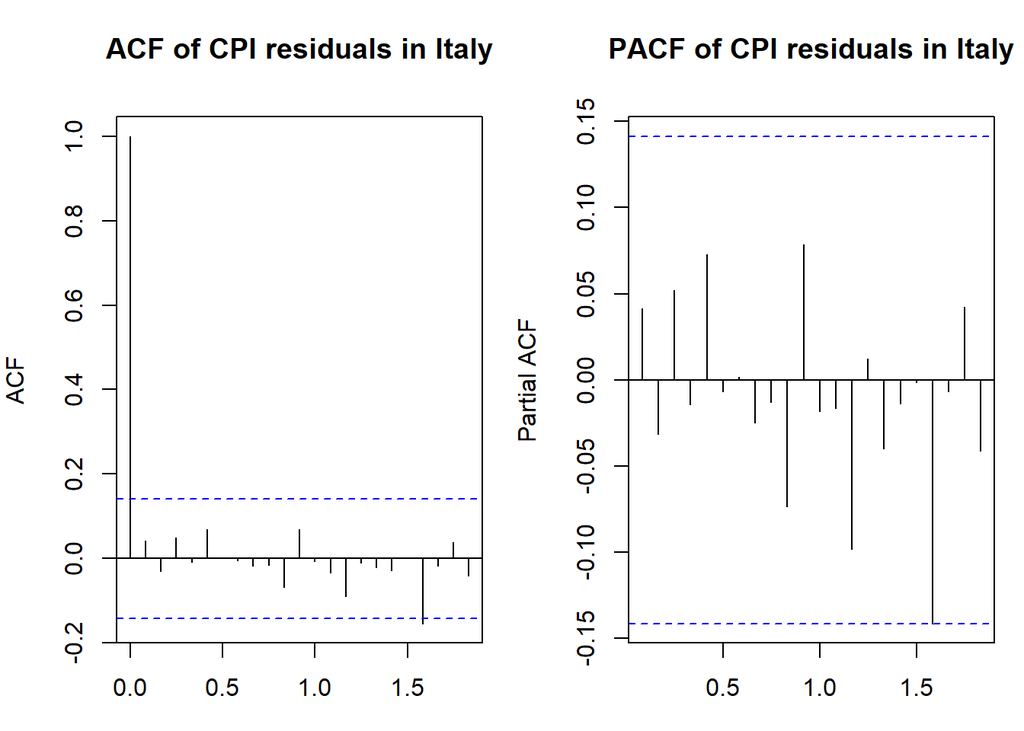

```r
plot_residuals_arima(seasonal_4_6_i_c, "Italy", "CPI")
```

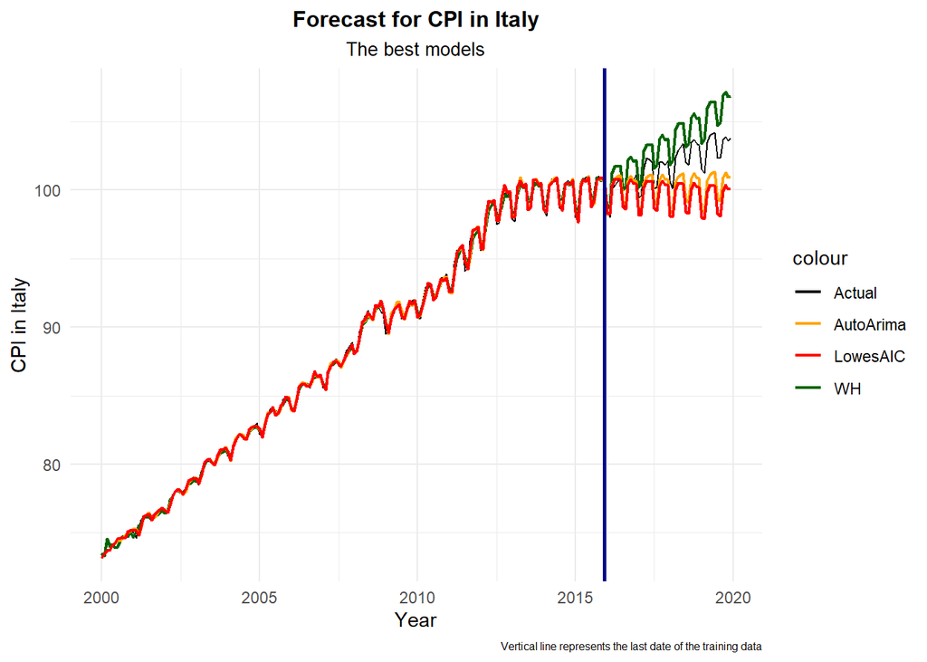

```r
plot_forecast_arima_3 <- function(train_data, test_data, ts_data, country, variable, wh, arima1, arima2) {
  ntest <- length(test_data)

  # Extract the last date of the training data
  last_date_train <- tail(time(train_data), 1)

  ggplot(data.frame(time = time(ts_data), value = ts_data, pred_arima = arima1)) +
    geom_line(aes(x = time, y = value, group = 1, color = "Actual")) +

    geom_line(aes(x = time, y = wh, group = 1, color = "WH"), size=0.75) +
    geom_line(aes(x = time, y = arima1, group = 2, color = "AutoArima"), size=0.75) +
    geom_line(aes(x = time, y = arima2, group = 3, color = "LowesAIC"), size=0.75) +

    geom_vline(aes(xintercept = as.numeric(last_date_train)), color = "darkblue", size = 0.9) +
    xlab("Year") +
    ylab(paste(variable, "in", country)) +
    labs(title = paste("Forecast for", variable, "in", country),
         subtitle = paste("The best models"),
         caption = "Vertical line represents the last date of the training data") +
    theme_minimal() +
    theme(plot.title = element_text(size = 12, face = "bold", hjust = 0.5),
          plot.subtitle = element_text(size = 10, hjust = 0.5),
          plot.caption = element_text(size = 6)) +
    scale_color_manual(values = c("Actual" = "black", "WH" = "darkgreen", "AutoArima" = "orange", "LowesAIC" = "red"))
}



model_hw <- ets(cpi_italy_train, model = 'AAA', alpha = 0.7)
ntest <- length(cpi_italy_test)
pred <- forecast(model_hw, h = ntest, level = 0)
pred_hw <- c(model_hw$fitted, pred$mean)

pred <- forecast(model_aic_i_cpi, h = ntest, level = 0)
pred_arima1 <- c(model_aic_i_cpi$fitted, pred$mean)

pred <- forecast(seasonal_4_6_i_c, h = ntest, level = 0)
pred_arima2 <- c(seasonal_4_6_i_c$fitted, pred$mean)


plot_forecast_arima_3(cpi_italy_train, cpi_italy_test, transformed_italy$cpi, "Italy", "CPI", pred_hw, pred_arima1, pred_arima2)
```

Here several ARIMA models were used alongside winter-holts to capture the trend and seasonality within the CPI data. Although all these models properly model the training data, the test data could not be captured accurately by our modeling. Overall Winter-holt had the best prediction for the direction of the trend. Also the differenc between the auto.arima model as well as the one with the lowes AIC wich has 6 periods for the seasonal componant perform very similar. This shows how important it is to use different methods. Here further combination might lead to the best result. When decision makers relay on only the Arima they might underestimate the inflaiton whereas the Winter-Holt method might overestimate it.

### 2.2.3 Stocks Italy

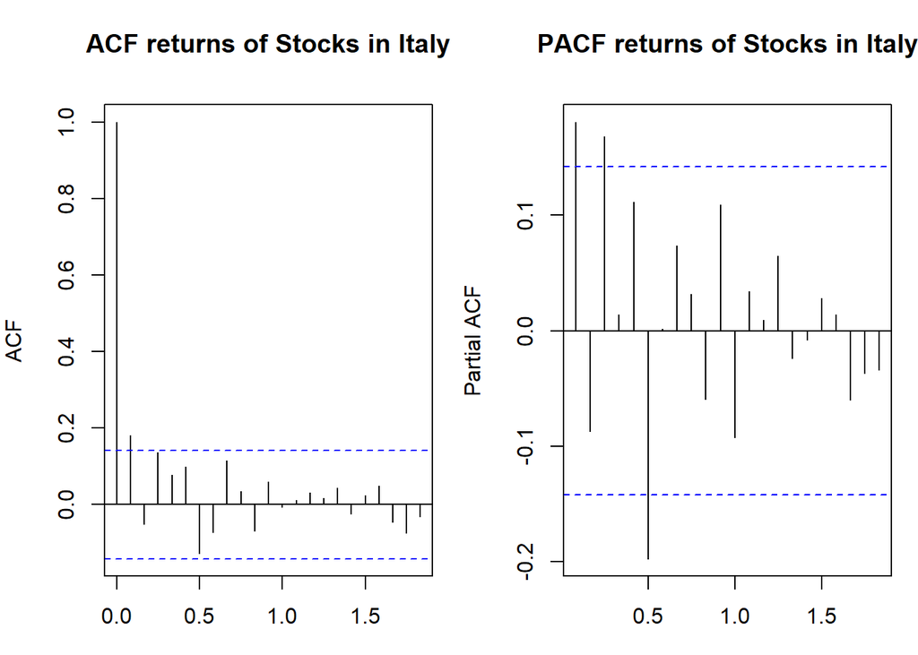

```r
# define a function
returns_evauate <- function(ts_data, country, variable) {

  # Set up the plot
  par(mfrow = c(1, 2), mar = c(3, 4, 4, 1))

  # ACF and PACF plots
  acf(ts_data, main = paste("ACF returns of", variable, "in", country))
  pacf(ts_data, main = paste("PACF returns of", variable, "in", country))
}

# log difference
dl_st_i_train <- diff(log(stocks_italy_train))

returns_evauate(dl_st_i_train, "Italy", "Stocks")
```

```r
evaluate_garch_models <- function(models) {

  results <- data.frame(Model = character(), AIC = numeric(), BIC = numeric(), Residuals = character())

  for (i in seq_along(models)) {

    model <- models[[i]]

    garch_info <- infocriteria(model)

    # Extract AIC and SIC
    aic <-  garch_info[1]
    bic <-  garch_info[2]

    # Check residuals for white noise
    white_noise <- Box.test(residuals(model), lag = 20, type = "Ljung-Box")$p.value > 0.05
    residuals_check <- ifelse(white_noise, "White Noise", "Not White Noise")

    # Append results to the data frame
    name <- paste("Model", i)
    result_row <- data.frame(Model = name, AIC = aic, BIC = bic, Residuals = residuals_check)
    results <- rbind(results, result_row)
  }

  return(results)
}

a1 <- ugarchfit(ugarchspec(variance.model = list(model = "sGARCH", garchOrder = c(1, 0)), distribution.model = "std"), data = stocks_italy_train)
a2 <- ugarchfit(ugarchspec(variance.model = list(model = "sGARCH", garchOrder = c(2, 0)), distribution.model = "std"), data = stocks_italy_train)
a3 <- ugarchfit(ugarchspec(variance.model = list(model = "sGARCH", garchOrder = c(3, 0)), distribution.model = "std"), data = stocks_italy_train)
a4 <- ugarchfit(ugarchspec(variance.model = list(model = "sGARCH", garchOrder = c(4, 0)), distribution.model = "std"), data = stocks_italy_train)
a5 <- ugarchfit(ugarchspec(variance.model = list(model = "sGARCH", garchOrder = c(5, 0)), distribution.model = "std"), data = stocks_italy_train)
a6 <- ugarchfit(ugarchspec(variance.model = list(model = "sGARCH", garchOrder = c(6, 0)), distribution.model = "std"), data = stocks_italy_train)
a7 <- ugarchfit(ugarchspec(variance.model = list(model = "sGARCH", garchOrder = c(7, 0)), distribution.model = "std"), data = stocks_italy_train)

g1 <- ugarchfit(ugarchspec(variance.model = list(model = "gjrGARCH", garchOrder = c(1, 1)), distribution.model = "std"), data = stocks_italy_train)
g2 <- ugarchfit(ugarchspec(variance.model = list(model = "gjrGARCH", garchOrder = c(2, 2)), distribution.model = "std"), data = stocks_italy_train)
g3 <- ugarchfit(ugarchspec(variance.model = list(model = "gjrGARCH", garchOrder = c(3, 3)), distribution.model = "std"), data = stocks_italy_train)

model_list <- list(a1, a2, a3, a4, a5, a6, a7, g1, g2, g3)

evaluate_garch_models(model_list)
```

```
##       Model      AIC      BIC   Residuals
## 1   Model 1 6.123915 6.225711 White Noise
## 2   Model 2 6.123903 6.242666 White Noise
## 3   Model 3 6.117271 6.253000 White Noise
## 4   Model 4 6.126481 6.279176 White Noise
## 5   Model 5 6.134577 6.304238 White Noise
## 6   Model 6 6.119225 6.305853 White Noise
## 7   Model 7 6.125100 6.328693 White Noise
## 8   Model 8 6.088748 6.224477 White Noise
## 9   Model 9 6.107047 6.293675 White Noise
## 10 Model 10 6.136826 6.374351 White Noise
```

Comparing the different models the lowes AIC was achived for the GARCH(1,1) model. This model was then used to predict the volatility of the stocks in italy.

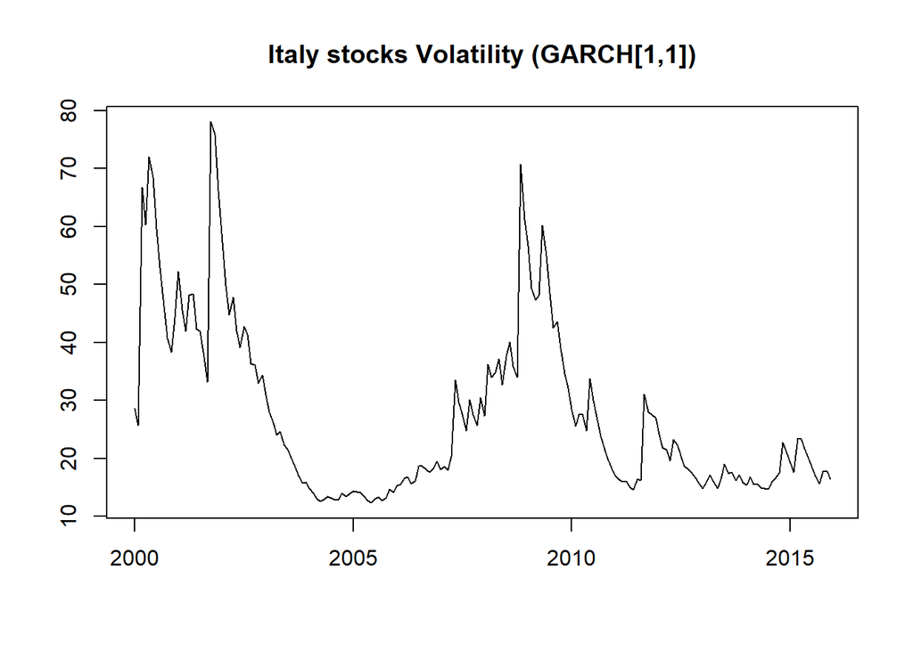

```r
vole <- ts(g1@fit$sigma^2,end=c(2015,12),frequency = 12)
plot(vole,xlab="",ylab="",main="Italy stocks Volatility (GARCH[1,1])")
```

GARCH model was used due to observed volatility in the data, as observed in 2000-2002 the model properly models the dot com bubble, and then in 2007 the housing crisis. The model is also consistent with the crisis that where modeled with the GDP, showing that the stock data of italy is closely related to the country’s GDP data. This can help decision makers to use information from different data sources becuase it shows that the stock market can already early show signs of volatility and this often indecates a crisis which then the decision makers can use to prevent the crisis from happening.

### 2.2.4 GDP USA

```r
# Creating different models
model_min_u_gdp <- forecast::Arima(gdp_usa_train, order = c(1, 1, 0))
model_drift_u_gdp <- forecast::Arima(gdp_usa_train, order = c(1, 1, 0), include.drift = TRUE)
model_aic_u_gdp <- auto.arima(gdp_usa_train, ic = 'aic')
model_bic_u_gdp <- auto.arima(gdp_usa_train, ic = 'bic')

# Create a list of models
model_list <- list(model_min_u_gdp, model_drift_u_gdp, model_aic_u_gdp, model_bic_u_gdp)

# Evaluate the models
evaluate_arima_models(model_list, gdp_usa_test)
```

```
##                    Model      AIC      SIC      BIC   Residuals      MSPE
## 1 ARIMA(1 1 0)(0 0 0)[4] 589.0906 593.4083 593.3768 White Noise 0.8085553
## 2 ARIMA(1 1 0)(0 0 0)[4] 576.4001 582.8768 582.8295 White Noise 0.1621864
## 3 ARIMA(1 1 0)(0 0 0)[4] 576.4001 582.8768 582.8295 White Noise 0.1621864
## 4 ARIMA(1 1 0)(0 0 0)[4] 576.4001 582.8768 582.8295 White Noise 0.1621864
```

Here we take into account several models, the first considers the highest lag within the different data’s ACF and PACF to create the model. For the second model we identified that the data was not fully stationary after differencing so we took into account drift to get the data stationary. The last 2 models take into account the lowest aic and bic.

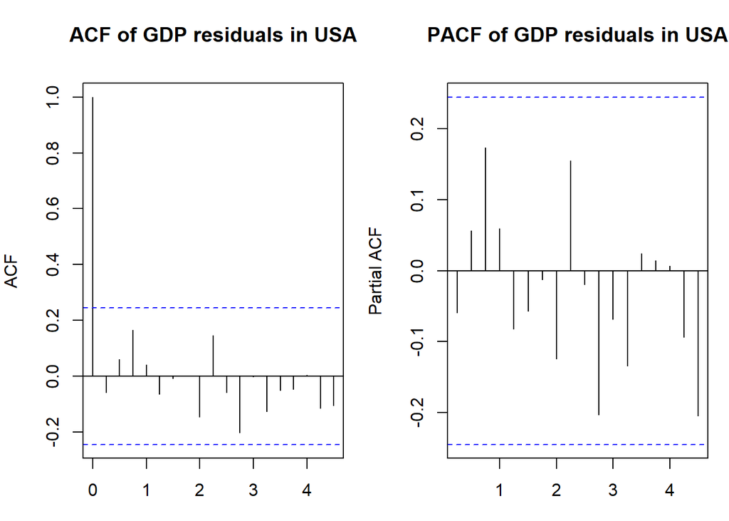

```r
# Plot the residuals of the best model
plot_residuals_arima(model_aic_u_gdp, "USA", "GDP")
```

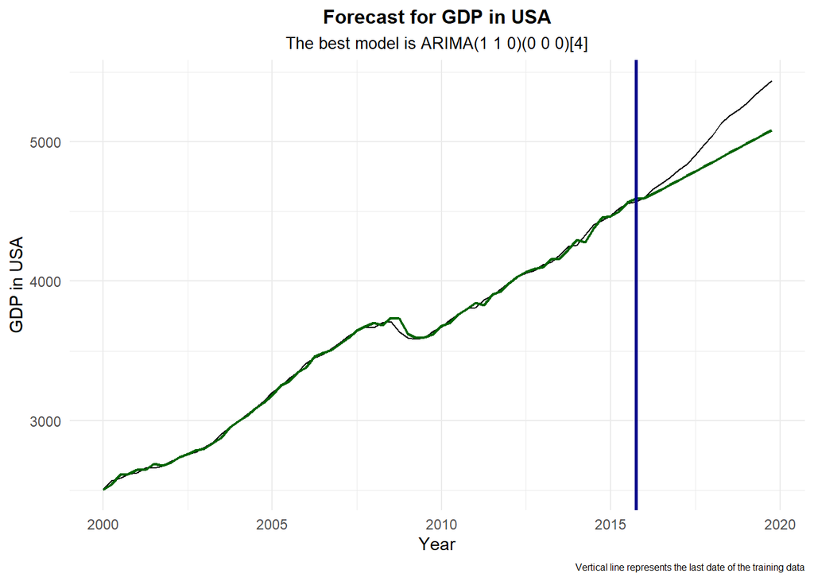

```r
plot_forecast_arima(gdp_usa_train, gdp_usa_test, transformed_usa$gdp, "USA", "GDP", model_aic_u_gdp)
```

Our model uses our best forecast, lowest aic model with ARIMA, and underestimates growth. This is clearly visible in the test data. Here models with higher growth components maybe even exponential growth components could be used to better model the data. It is important to know the limitations of the models and potential problems because decision makers need to know if the predictions are reliable. To make good use. But still with this model the USA can in the short term estimate the growth of the GDP properly.

### 2.2.5 CPI USA

```r
# Creating different models
model_min_u_cpi <- forecast::Arima(cpi_usa_train, order = c(1, 1, 0))

model_aic_u_cpi <- auto.arima(cpi_usa_train, ic = 'aic')
model_bic_u_cpi <- auto.arima(cpi_usa_train, ic = 'bic')

# Create a list of models
model_list <- list(model_min_u_cpi, model_aic_u_cpi, model_bic_u_cpi)

# Evaluate the models
evaluate_arima_models(model_list, cpi_usa_test)
```

```
##                     Model      AIC      SIC      BIC       Residuals       MSPE
## 1 ARIMA(1 1 0)(0 0 0)[12] 393.3472 399.8622 399.8517 Not White Noise 0.30661234
## 2 ARIMA(2 1 0)(0 0 0)[12] 374.7228 387.7528 387.7319     White Noise 0.01974443
## 3 ARIMA(0 1 2)(0 0 0)[12] 375.0817 388.1117 388.0908     White Noise 0.02464080
```

Models incorporating drift (ARIMA(2,1,0) and ARIMA(0,1,2)) have lower AIC values, signifying improved fit and suggesting that the inclusion of a linear trend enhances the accuracy in capturing the underlying time series structure.

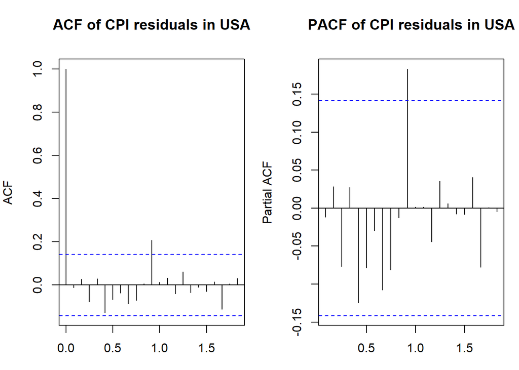

```r
plot_residuals_arima(model_aic_u_cpi, "USA", "CPI")
```

Because the residuals, when plotted in ACF and PACF show some violations, it tells us that there is still information to be extracted from the data that our previous models did not capture. Therefore other models will be used to try and understand the remaining violations of the PACF and ACF.

```r
simplify_arima <- function(model, data, drift = F, significance_level = 0.05) {
  # Extract coefficients and standard errors
  coefficients <- coef(model)
  cov_matrix <- model$var.coef
  standard_errors <- sqrt(diag(cov_matrix))

  # Identify non-significant parameters
  non_significant <- abs(coefficients) < standard_errors * qnorm(1 - significance_level / 2)

  # set all values in coefficients to NA
  coefficients <- NA
  coefficients[non_significant] <- 0

  # add one NA
  if (drift){
    coefficients <- c(coefficients, NA)}

  # Fit the simplified model
  order <- arimaorder(model)

  simplified_model <- forecast::Arima(data, order = order, fixed = coefficients, include.drift = drift)

  return(simplified_model)
}
# Example usage:
max_model <- forecast::Arima(cpi_usa_train, order = c(11, 1, 0))
simplified_model_ar <- simplify_arima(max_model, cpi_usa_train, drift = TRUE)

max_model <- forecast::Arima(cpi_usa_train, order = c(0, 1, 11))
simplified_model_ma <- simplify_arima(max_model, cpi_usa_train, drift = TRUE)

model_list <- list(model_aic_u_cpi, simplified_model_ar, simplified_model_ma)

# Evauate model
evaluate_arima_models(model_list, cpi_usa_test)
```

```
##                      Model      AIC      SIC      BIC   Residuals       MSPE
## 1  ARIMA(2 1 0)(0 0 0)[12] 374.7228 387.7528 387.7319 White Noise 0.01974443
## 2 ARIMA(11 1 0)(0 0 0)[12] 377.2029 390.2328 390.2119 White Noise 0.03777257
## 3 ARIMA(0 1 11)(0 0 0)[12] 372.2149 388.5024 388.4763 White Noise 0.02357981
```

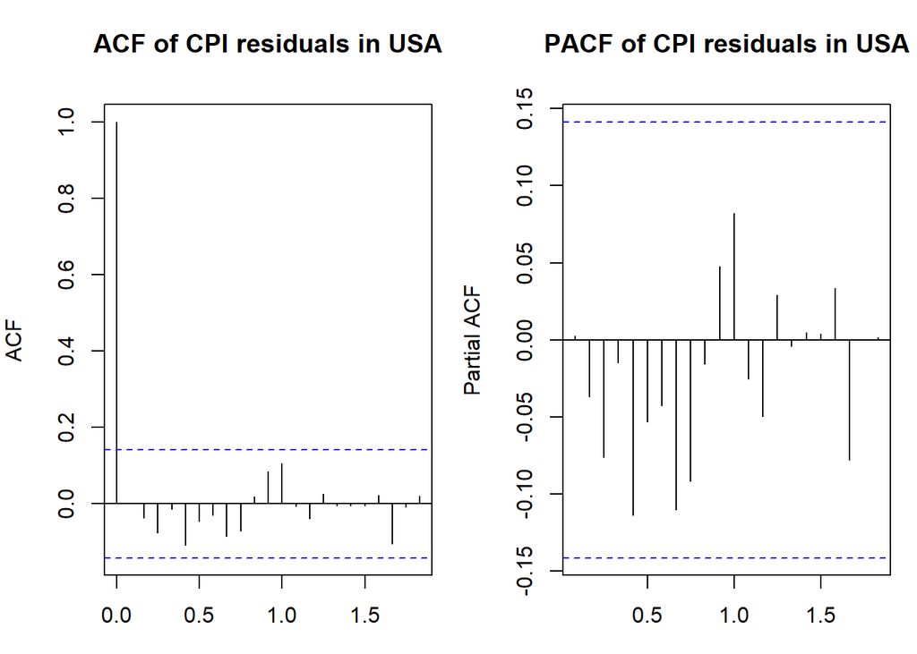

```r
plot_residuals_arima(simplified_model_ma, "USA", "CPI")
```

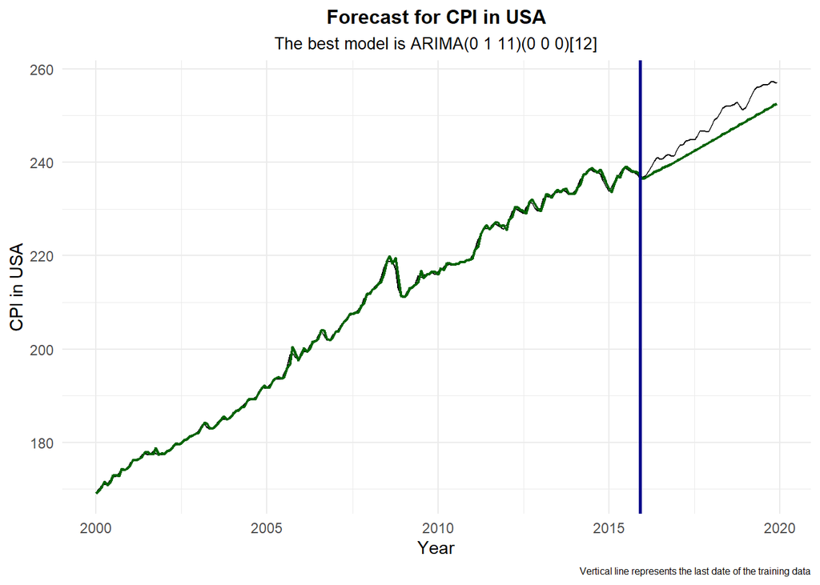

```r
plot_forecast_arima(cpi_usa_train, cpi_usa_test, transformed_usa$cpi, "USA", "CPI", simplified_model_ma)
```

After evaluating multiple ARIMA models, the selected one highlights the challenge of accurately predicting future Consumer Price Index (CPI) trends. While the model effectively captures general trends, its limitations in precisely forecasting specific patterns are evident, particularly considering the univariate nature of ARIMA. This is exemplified in the USA and also earlier in the Italy data, where the model indicates a stronger rise in CPI than predicted.

### 2.2.6 Stocks USA

[figure not shown]

```r
# log difference
dl_st_i_train <- diff(log(stocks_usa_train))

returns_evauate(dl_st_i_train, "Italy", "Stocks")
```

```r
a1 <- ugarchfit(ugarchspec(variance.model = list(model = "sGARCH", garchOrder = c(1, 0)), distribution.model = "std"), data = stocks_usa_train)
a2 <- ugarchfit(ugarchspec(variance.model = list(model = "sGARCH", garchOrder = c(2, 0)), distribution.model = "std"), data = stocks_usa_train)
a3 <- ugarchfit(ugarchspec(variance.model = list(model = "sGARCH", garchOrder = c(3, 0)), distribution.model = "std"), data = stocks_usa_train)
a4 <- ugarchfit(ugarchspec(variance.model = list(model = "sGARCH", garchOrder = c(4, 0)), distribution.model = "std"), data = stocks_usa_train)
a5 <- ugarchfit(ugarchspec(variance.model = list(model = "sGARCH", garchOrder = c(5, 0)), distribution.model = "std"), data = stocks_usa_train)
a6 <- ugarchfit(ugarchspec(variance.model = list(model = "sGARCH", garchOrder = c(6, 0)), distribution.model = "std"), data = stocks_usa_train)
a7 <- ugarchfit(ugarchspec(variance.model = list(model = "sGARCH", garchOrder = c(7, 0)), distribution.model = "std"), data = stocks_usa_train)

g1 <- ugarchfit(ugarchspec(variance.model = list(model = "gjrGARCH", garchOrder = c(1, 1)), distribution.model = "std"), data = stocks_usa_train)
g2 <- ugarchfit(ugarchspec(variance.model = list(model = "gjrGARCH", garchOrder = c(2, 2)), distribution.model = "std"), data = stocks_usa_train)
g3 <- ugarchfit(ugarchspec(variance.model = list(model = "gjrGARCH", garchOrder = c(3, 3)), distribution.model = "std"), data = stocks_usa_train)

model_list <- list(a1, a2, a3, a4, a5, a6, a7, g1, g2, g3)

evaluate_garch_models(model_list)
```

```
##       Model      AIC      BIC   Residuals
## 1   Model 1 4.686344 4.788141 White Noise
## 2   Model 2 4.696394 4.815157 White Noise
## 3   Model 3 4.706766 4.842495 White Noise
## 4   Model 4 4.707459 4.860154 White Noise
## 5   Model 5 4.715186 4.884847 White Noise
## 6   Model 6 4.703261 4.889888 White Noise
## 7   Model 7 4.713578 4.917172 White Noise
## 8   Model 8 4.678244 4.813973 White Noise
## 9   Model 9 4.720678 4.907306 White Noise
## 10 Model 10 4.766112 5.003638 White Noise
```

Here we take into consideration several ARCH and GARCH models to evaluate them by the lowest AIC, which leads us to the most accurate model.

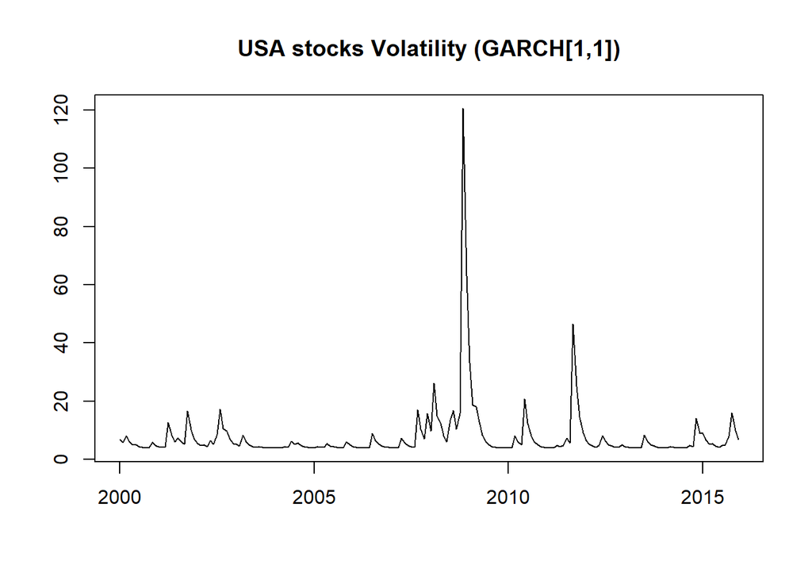

```r
vole <- ts(g1@fit$sigma^2,end=c(2015,12),frequency = 12)
plot(vole,xlab="",ylab="",main="USA stocks Volatility (GARCH[1,1])")
```

We can see a very accurate model which captures the housing crisis as well as economic uncertainties in 2012 well. Also comparing his with the GDP in the USA it showed that this is again correlated and had a negative effect on the GDP. This correlation can again be used by decision makers to keep the economy healthy.

# Conclusion

In conclusion, our project reveals a close interrelation among the analyzed variables, particularly evident in the comparison between the US and Italy. Notably, the US GDP exhibited robust and non-seasonal growth, outpacing Italy. The US Consumer Price Index (CPI) also displayed a faster rate of increase. Both show that the economy in the USA is stronger, and the forecast might help to improve both economies further by simultaneously keeping the inflation rate in check. This balance is very important to maintain a healthy economy. Also, the distinct impacts of the housing crisis on stocks and GDP further underscore the complexity of these interconnected economic factors.

Looking ahead, both economies show an upward trend, but our models highlight a concerning rise in inflation. This emphasizes the importance of focusing on inflation in the fiscal policy agendas of both governments to ensure sustainable economic growth and stability.

# References

The 2015 annual report at a glance: https://www.bancaditalia.it/pubblicazioni/relazione-annuale/2015/sintesi/index.html?com.dotmarketing.htmlpage.language=1&dotcache=refresh.

Ardeni, P. G. and Gallegati, M.: On italian economic development: What the long-term says about the short-term, Italian Economic Journal, https://doi.org/10.1007/s40797-023-00219-5, 2023.

Ayyoub, M., Chaudhry, I. S., and Farooq, F.: Does inflation affect economic growth? The case of pakistan, Pakistan Journal of Social Sciences (PJSS), 31, 51–64, 2011.

Cobb, C., Halstead, T., and Rowe, J.: [If the GDP is up, why is america down?](http://www.theatlantic.com/politics/ecbig/gdp.htm), The Atlantic Monthly, 1995.

Lessons from italy’s economic decline: https://economy2030.resolutionfoundation.org/wp-content/uploads/2022/11/Lessons-from-Italys-economic-decline_.pdf.

Ghazo, A.: Applying the ARIMA model to the process of forecasting GDP and CPI in the jordanian economy, International Journal of Financial Research, 12, 70, https://doi.org/10.5430/IJFR.V12N3P70, 2021.

Guha Deb, S. and Mukherjee, J.: Does stock market development cause economic growth? A time series analysis for indian economy, International Research Journal of Finance and Economics, 21, 2008.

Liu, H., Manzoor, A., Wang, C., Zhang, L., and Manzoor, Z.: The COVID-19 outbreak and affected countries stock markets response, International Journal of Environmental Research and Public Health, 17, https://doi.org/10.3390/ijerph17082800, 2020.

Mahmoud, L. O. M.: Consumer price index and economic growth: A case study of mauritania 1990–2013, Asian Journal of Empirical Research, 5, 16–23, 2015.

Namin, S. S. and Namin, A. S.: Forecasting economic and financial time series: ARIMA vs. LSTM, Texas Tech University, 2018.